# WFC198_Bolas_Hwk3_logistic_and_poisson

## Task 3: Analyzing Poisson regression data

The data file “HW3data.csv” contains two columns, “Species”, showing the number of bird species detected at a given site (response variable, count), and “Quality”, and index of habitat quality at that site (predictor variable), where higher numbers indicate higher quality.

1. Read the data file into R and perform a Poisson regression (with the covariate) on the data (2 Pts)

```r
getwd()
```

```
## [1] "C:/Users/ebola/Google Drive/Git/WFC198_Git/WFC198/Lab3_Hwk3"
```

```r
birddat <- read.csv("HW3data.csv")
head(birddat)
```

```
##   Species  Quality
## 1       6 1.920514
## 2       5 2.150402
## 3       7 1.505326
## 4       5 1.933705
## 5       5 1.652852
## 6       5 1.851024
```

```r
poismod <- glm(Species~Quality, data= birddat, family = "poisson")
summary(poismod)
```

```
##
## Call:
## glm(formula = Species ~ Quality, family = "poisson", data = birddat)
##
## Deviance Residuals:
##      Min        1Q    Median        3Q       Max
## -2.70274  -0.33175  -0.04382   0.39331   1.29872
##
## Coefficients:
##             Estimate Std. Error z value Pr(>|z|)
## (Intercept)   1.1422     0.1267   9.017  < 2e-16 ***
## Quality       0.2672     0.0840   3.181  0.00147 **
## ---
## Signif. codes:  0 '***' 0.001 '**' 0.01 '*' 0.05 '.' 0.1 ' ' 1
##
## (Dispersion parameter for poisson family taken to be 1)
##
##     Null deviance: 70.158  on 96  degrees of freedom
## Residual deviance: 59.439  on 95  degrees of freedom
## AIC: 377.1
##
## Number of Fisher Scoring iterations: 5
```

```r
#intercept: 1.1422, slope: 0.2672
```

2. Generate expected values of Y on the response scale based on the model fit under a) for a sequence of habitat quality values, ranging from the minimum observed quality to the maximum observed quality, at intervals of 0.1 (2 Pts)

```r
#need to generate a new set of x based on the min and max of the original data

minbird <- min(birddat$Quality)
maxbird <- max(birddat$Quality)
#newx2 <- data.frame(z = seq(minbird, maxbird, 0.1)) here, bc I re-named the column z, predict.glm got confused and couldn't find the Quality variable. Use the same variable name throughout
newx2 <- data.frame(Quality = seq(minbird, maxbird, 0.1))
newx2 #this will give us the expected values for the full length of x, gives a more complete sequence
```

```
##        Quality
## 1  -0.95971684
## 2  -0.85971684
## 3  -0.75971684
## 4  -0.65971684
## 5  -0.55971684
## 6  -0.45971684
## 7  -0.35971684
## 8  -0.25971684
## 9  -0.15971684
## 10 -0.05971684
## 11  0.04028316
## 12  0.14028316
## 13  0.24028316
## 14  0.34028316
```

[output cut: 20 more lines]

```r
#now calculate expected y on response scale
exp.y2 <- predict.glm(object=poismod, newdata= newx2, type = "response", se.fit =T)
exp.y2
```

```
## $fit
##        1        2        3        4        5        6        7        8
## 2.425000 2.490660 2.558096 2.627359 2.698498 2.771562 2.846605 2.923679
##        9       10       11       12       13       14       15       16
## 3.002840 3.084145 3.167651 3.253418 3.341508 3.431982 3.524906 3.620347
##       17       18       19       20       21       22       23       24
## 3.718371 3.819049 3.922454 4.028658 4.137738 4.249771 4.364837 4.483019
##       25       26       27       28       29       30       31       32
## 4.604401 4.729070 4.857114 4.988625 5.123696 5.262425 5.404910 5.551253
##       33       34
## 5.701559 5.855934
##
## $se.fit
##         1         2         3         4         5         6         7
## 0.4937330 0.4867922 0.4791690 0.4708410 0.4617868 0.4519868 0.4414240
##         8         9        10        11        12        13        14
## 0.4300851 0.4179616 0.4050520 0.3913640 0.3769179 0.3617519 0.3459281
##        15        16        17        18        19        20        21
## 0.3295419 0.3127357 0.2957168 0.2787831 0.2623575 0.2470291 0.2335954
##        22        23        24        25        26        27        28
## 0.2230835 0.2167091 0.2157262 0.2211702 0.2336055 0.2530401 0.2790567
##        29        30        31        32        33        34
## 0.3110421 0.3483775 0.3905381 0.4371222 0.4878440 0.5425136
##
## $residual.scale
## [1] 1
```

3. Plot these expected values against the range of habitat quality values generated in b). Adjust the y axis to range from 0 to 7 using the ylim argument**. Label your axes appropriately. (2 Pts).

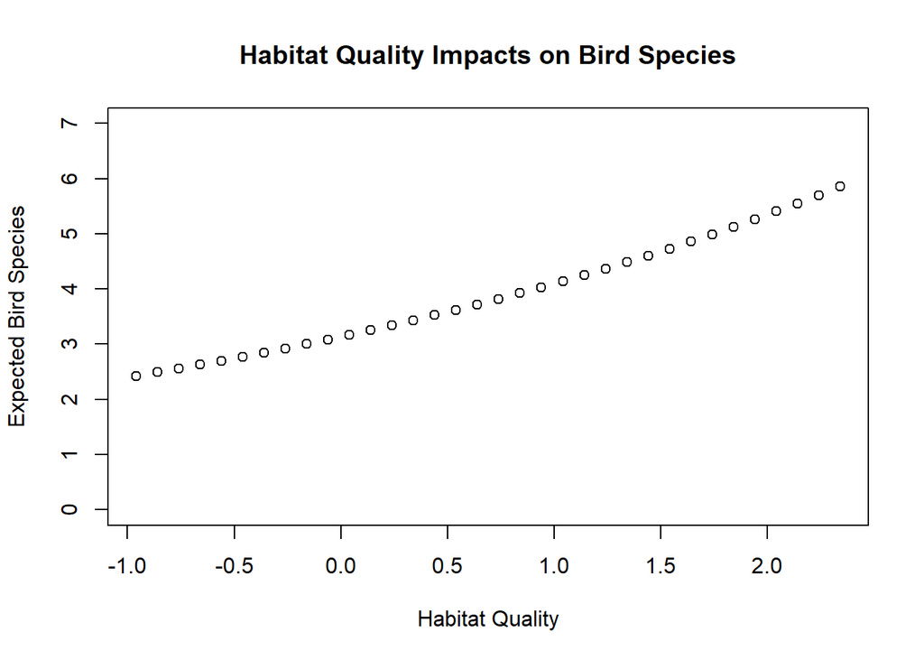

```r
#remember that "fit" is the expected y values
plot(newx2$Quality, exp.y2$fit, main = "Habitat Quality Impacts on Bird Species", xlab = "Habitat Quality", ylab = "Expected Bird Species", ylim = c(0,7))
```

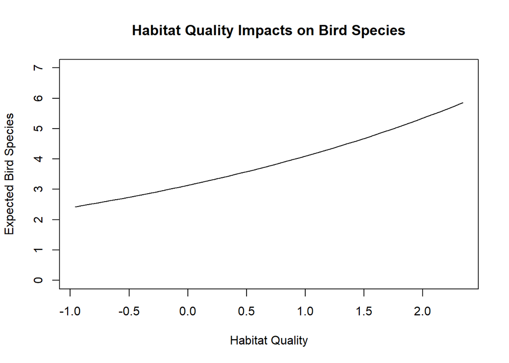

```r
#should it be a line?
plot(newx2$Quality, exp.y2$fit, main = "Habitat Quality Impacts on Bird Species", xlab = "Habitat Quality", ylab = "Expected Bird Species", ylim = c(0,7), type = "l")
```

4. Add the observations to the plot generated in c). (1 Pt)

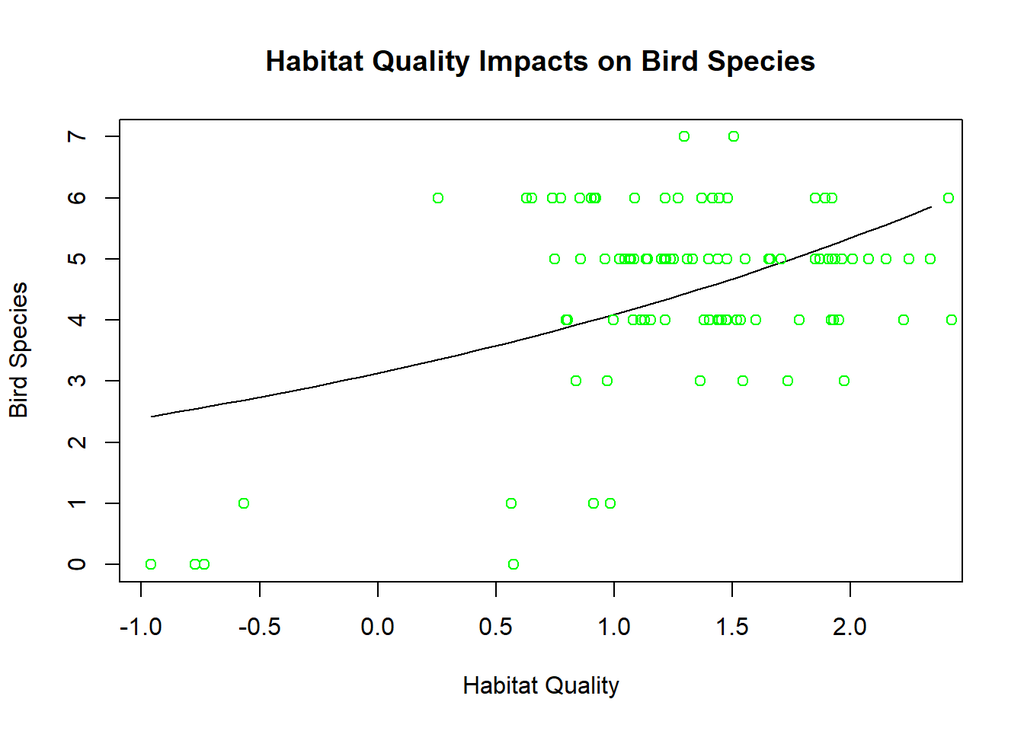

```r
plot(newx2$Quality, exp.y2$fit, main = "Habitat Quality Impacts on Bird Species", xlab = "Habitat Quality", ylab = "Bird Species", ylim = c(0,7), type = "l") #plotted model as a line, data as points
points(birddat$Quality, birddat$Species, col = "green")
```

## Question 5 (not an R question): (4 Pts)

Interpret the results from the Poisson regression in Q3. In 2-3 sentences, quantitatively*** describe the effect of the predictor variable on the response variable (both direction and magnitude; use units); what the null hypothesis is in this context, which decision you make about the null hypothesis, based on what part of the results. Type your answer into your R script; remember to comment it out, since it is not code! Please use line breaks, rather than writing everything into one very long line. **By that I mean, it is not enough to say the effect is positive or negative, strong or weak, you need to use the parameter estimate in your description, and explain what that number means in the context of this example.

## Answer:

The null hypotheses is that there is no relationship between habitat quality and number of bird species present. However, data indicate that habitat quality has a positive relationship (0.2672) with number of bird species present that is highly significant (p = 0.00147). This means that the null hypothesis can be be rejected, and we can conclude that increased habitat quality yields increased abundance of bird species.